# Transect Report Lone Cabbage

# Overview

This report provides summary statistics and figures for ongoing transect sampling. The first section of the report focuses on the current sampling (Winter 2022-2023) and how the collected data compare to last year’s sampling (Winter 2021-2022). So far 12 days have been sampled this season. The second half of the report gives summaries of all of the data that have been collected since the beginning of the project (2010-05-27). In total, 156 days have been sampled over this entire project.

## Definition of Localities

| LOCALITY | LOCATION |
| --- | --- |
| BT | Big Trout |
| CK | Cedar Key |
| CR | Corrigan’s Reef |
| HB | Horseshoe Beach |
| LC | Lone Cabbage |
| LT | Little Trout |
| NN | No Name |

## Definition of Strata

| STRATA | DEFINITION |
| --- | --- |
| Y_N | Yes Harvest, No Rock |
| Y_Y | Yes Harvest, Yes Rock |
| N_N | No Harvest, No Rock |
| N_Y | No Harvest, Yes Rock |
| N_PILOT | No Harvest, Pilot Rocks |

# Current Sampling

Here, we provide a progress bar showing how much of the sampling has been completed for this season, plus summary tables and plots comparing live counts and density of oysters between this current season and last year. **The current sampling period is period 26, and last year’s sampling period is period 24.**

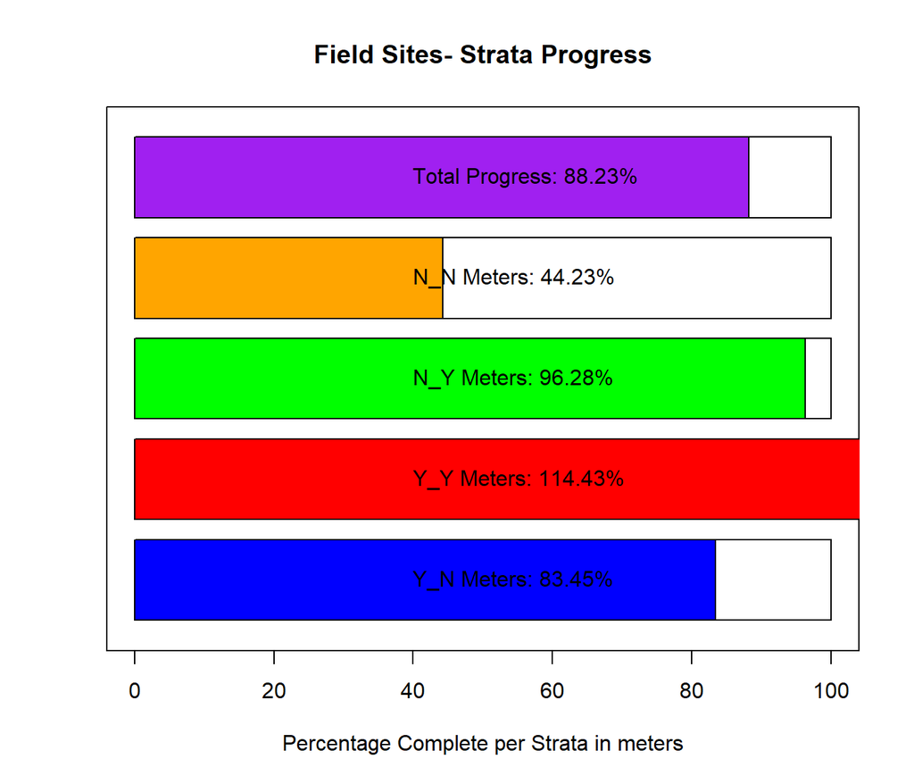

## Summary Tables for Periods 20, 22, 24, and 26

These summary tables provide summary statistics on live counts and oyster densities for just periods **20 (Winter 2019-2020), 22 (Winter 2020-2021), 24 (Winter 2021-2022), and 26 (Winter 2022-2023).**

Summary statistics include:  
- Locality or Strata or Period - Mean  
- Median  
- Standard Deviation (SD)  
- Variance (Var)  
- Coefficient of variation (CV)  
- Standard Error (SE)  
- Lower 95% Confidence Interval assuming normal distribution (L95)  
- Upper 95% Confidence Interval assuming normal distribution (U95)  
- Bootstrap Mean (Bstrap Mean)  
- Lower 95% Confidence Interval from Bootstrap Values (L95 Bstrap)  
- Upper 95% Confidence Interval from Bootstrap Values (U95 Bstrap)

Data are aggregated by station and period and then summarized in the tables below. Live counts are the number of live oysters summarized by locality, strata, and period, and density is the number of live oysters per square meter summarized by locality, strata, and period.

### Summary of Live Counts for Periods 20, 22, 24, and 26

```
Live Oyster Counts by Locality
 Locality Mean Median   SD     Var   CV  SE  L95  U95 Bstrap_Mean L95_Bstrap U95_Bstrap
       BT 1331    766 2188 4789476 1.64 607  141 2521        1334        579       2562
       LC 1918   1124 2151 4625507 1.12 190 1546 2291        1916       1577       2269
       LT 1097    877  582  338863 0.53 150  802 1392        1100        856       1430
       NN  842    714  639  408613 0.76 202  446 1238         842        494       1280

Live Oyster Counts by Strata
  Strata Mean Median   SD     Var   CV  SE  L95  U95 Bstrap_Mean L95_Bstrap U95_Bstrap
     N_N 1083    767 1185 1403189 1.09 154  781 1385        1089        855       1434
 N_PILOT 2180   3009 1582 2501624 0.73 913  390 3970        2182        356       3174
     N_Y 3650   3674 2182 4759072 0.60 412 2842 4458        3644       2839       4461
     Y_N  669    526  638  406598 0.95  84  505  833         672        514        847
     Y_Y 4236   3590 2753 7578661 0.65 649 2964 5508        4224       3001       5523

Live Oyster Counts by Period
 Period Mean Median   SD     Var  CV  SE  L95  U95 Bstrap_Mean L95_Bstrap U95_Bstrap
     20 1844   1253 2125 4517189 1.2 310 1236 2451        1841       1284       2482
     22 1334    702 1693 2867783 1.3 242  860 1808        1348        891       1836
     24 1729    942 1845 3403035 1.1 266 1207 2251        1727       1245       2222
     26 2394    730 2677 7164223 1.1 571 1276 3513        2401       1381       3533
```

```
Live Density by Locality
 Locality Mean Median  SD   Var   CV   SE L95 U95 Bstrap_Mean L95_Bstrap U95_Bstrap
       BT  235    205 192 37004 0.82 53.4 131 340         236        151        350
       LC  162    161 106 11281 0.66  9.4 143 180         162        145        182
       LT  320    321 129 16749 0.40 33.4 255 386         321        259        381
       NN  233    174 230 52911 0.99 72.7  91 376         231        124        374

Live Density by Strata
  Strata Mean Median  SD   Var   CV SE L95 U95 Bstrap_Mean L95_Bstrap U95_Bstrap
     N_N  239    192 163 26724 0.69 21 197 280         239        201        283
 N_PILOT  143    147  39  1557 0.28 23  98 188         142        102        180
     N_Y  172    180  74  5499 0.43 14 145 200         172        147        199
     Y_N  150    144 128 16508 0.85 17 117 184         151        122        188
     Y_Y  159    162  70  4834 0.44 16 126 191         158        128        190


Live Density by Period
 Period Mean Median  SD   Var   CV SE L95 U95 Bstrap_Mean L95_Bstrap U95_Bstrap
     20  256    203 187 35057 0.73 27 203 310         255        206        312
     22  137    121  93  8638 0.68 13 111 163         137        111        163
     24  185    181  92  8385 0.49 13 159 211         185        159        212
     26  148    168  94  8809 0.63 20 109 187         148        113        186
```

### Summary of Dead Counts for Periods 20, 22, 24, and 26

```
Dead Oyster Counts by Locality
 Locality Mean Median  SD   Var   CV SE L95 U95 Bstrap_Mean L95_Bstrap U95_Bstrap
       BT  163     98 175 30535 1.07 48  68 258         163         96        262
       LC  176    128 182 33305 1.04 16 144 207         176        146        206
       LT  206    137 151 22760 0.73 39 130 282         205        133        280
       NN  102     72  94  8760 0.92 30  44 160         102         57        164

Dead Oyster Counts by Strata
  Strata Mean Median  SD   Var   CV SE L95 U95 Bstrap_Mean L95_Bstrap U95_Bstrap
     N_N  171    115 167 27877 0.97 22 129 214         171        133        211
 N_PILOT  136    127 131 17150 0.97 76 -13 284         133          9        270
     N_Y  196    166 143 20537 0.73 27 143 249         195        149        251
     Y_N  113     66 124 15270 1.09 16  82 145         113         82        147
     Y_Y  346    269 269 72622 0.78 64 222 471         346        230        473

Dead Oyster Counts by Period
 Period Mean Median  SD   Var   CV SE L95 U95 Bstrap_Mean L95_Bstrap U95_Bstrap
     20  148    107 140 19727 0.95 20 108 188         148        113        186
     22  191    128 193 37399 1.01 28 137 245         192        143        251
     24  192    130 194 37816 1.01 28 137 247         191        142        248
     26  148     93 156 24439 1.06 33  84 211         147         87        213
```

```
Dead Oyster Density by Locality
 Locality Mean Median SD Var   CV  SE L95 U95 Bstrap_Mean L95_Bstrap U95_Bstrap
       BT   36     28 23 534 0.64 6.4  23  48          36         25         48
       LC   21     12 21 447 1.02 1.9  17  24          21         17         24
       LT   56     50 30 881 0.53 7.7  41  71          55         42         69
       NN   27     21 22 500 0.83 7.1  13  41          27         15         41

Dead Oyster Density by Strata
  Strata Mean Median   SD Var   CV   SE  L95 U95 Bstrap_Mean L95_Bstrap U95_Bstrap
     N_N 37.9   32.5 26.5 700 0.70 3.44 31.2  45        38.1       31.4         45
 N_PILOT  7.6    7.6  5.0  25 0.66 2.88  1.9  13         7.5        2.6         13
     N_Y  9.4    9.6  5.3  28 0.56 0.99  7.5  11         9.4        7.5         12
     Y_N 25.3   16.1 25.0 624 0.99 3.25 18.9  32        25.3       19.1         32
     Y_Y 12.3   13.1  4.8  23 0.39 1.13 10.1  15        12.4       10.3         14


Dead Oyster Density by Period
 Period Mean Median SD Var   CV  SE L95 U95 Bstrap_Mean L95_Bstrap U95_Bstrap
     20   28     18 26 682 0.94 3.8  20  35          28       20.3         35
     22   28     14 28 807 1.00 4.1  21  36          28       20.4         36
     24   26     19 21 438 0.81 3.0  20  32          26       20.2         32
     26   13     11 13 166 0.97 2.7   8  19          13        8.7         19
```

## Summary Plots for Periods 20, 22, 24, and 26

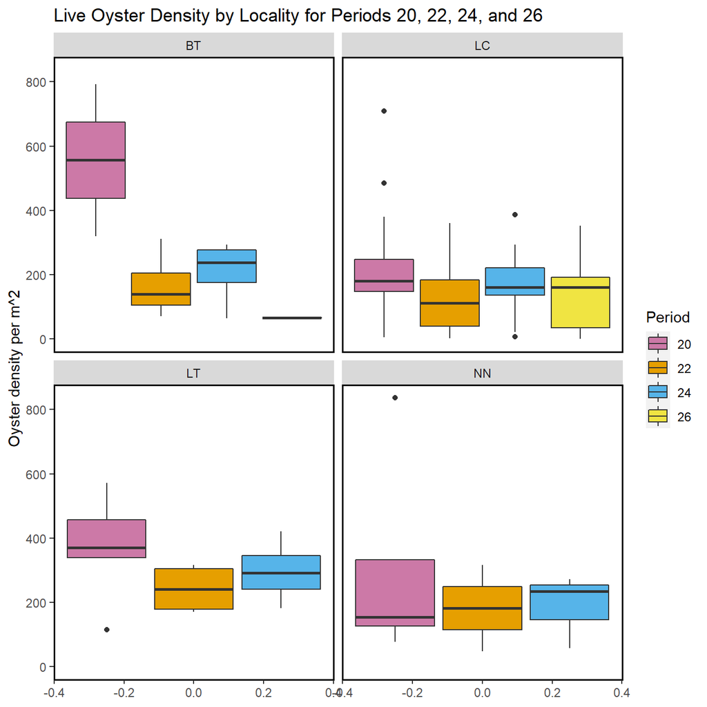

Figure- Calculated live oyster density by locality for periods 20 (Winter 2019-2020), 22 (Winter 2020-2021), 24 (Winter 2021-2022), and 26 (Winter 2022-2023) with the last sample date of period 26 as 2023-01-24.

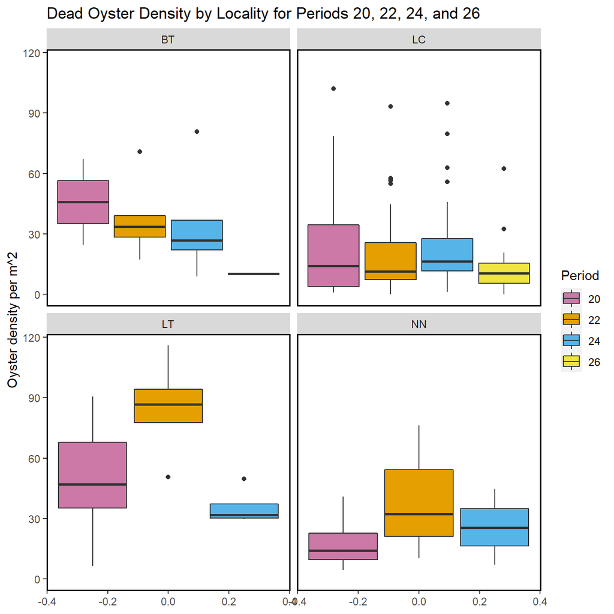

Figure- Calculated dead oyster density by locality for periods 20 (Winter 2019-2020), 22 (Winter 2020-2021), 24 (Winter 2021-2022), and 26 (Winter 2022-2023) with the last sample date of period 26 as 2023-01-24.

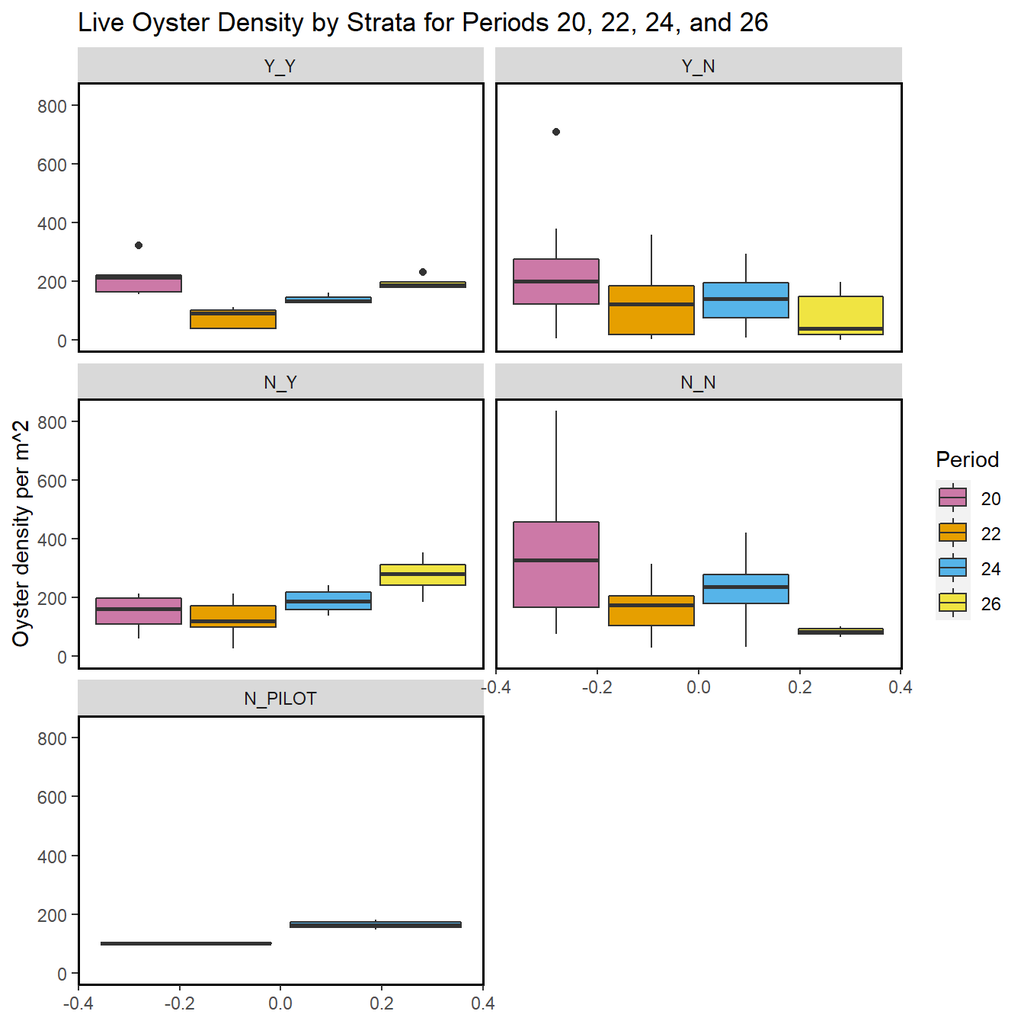

Figure- Calculated live oyster density by strata for periods 20 (Winter 2019-2020), 22 (Winter 2020-2021), 24 (Winter 2021-2022), and 26 (Winter 2022-2023) with the last sample date of period 26 as 2023-01-24.

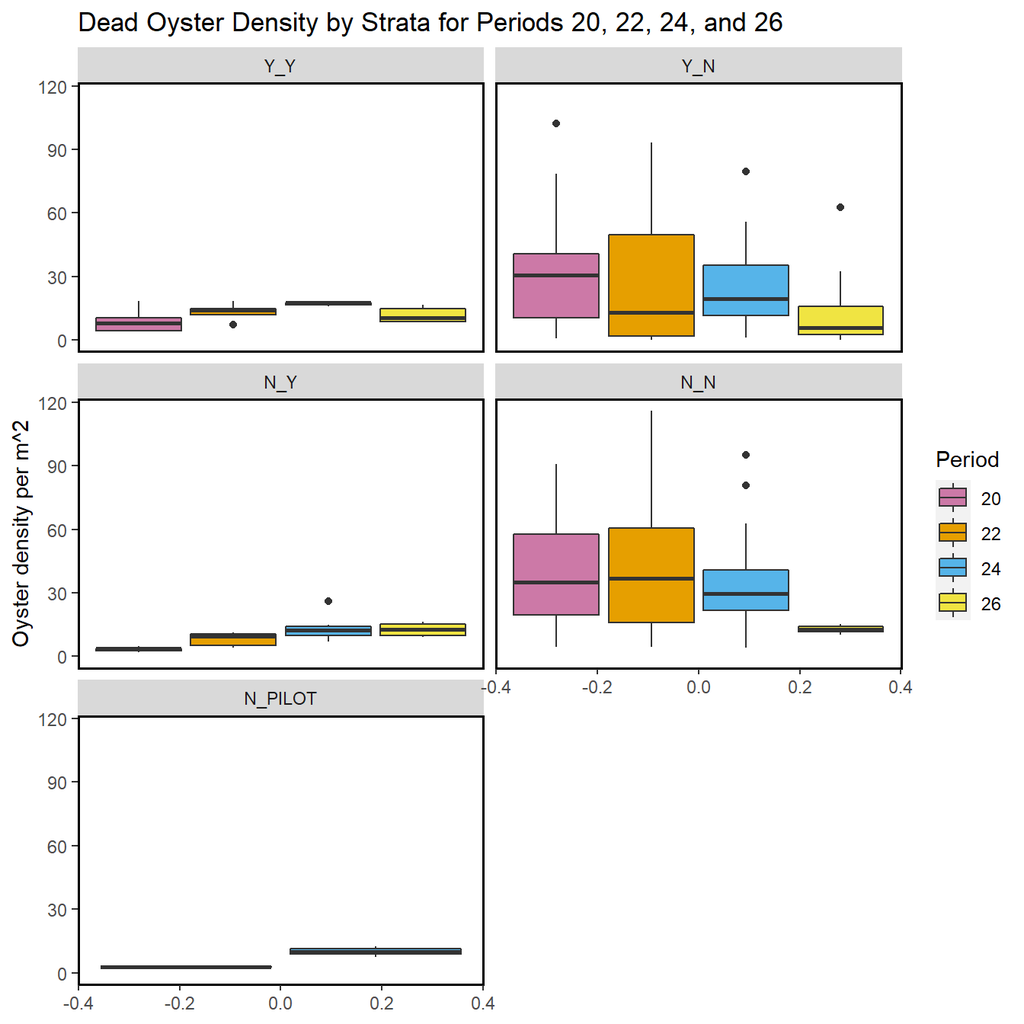

Figure- Calculated dead oyster density by strata for periods 20 (Winter 2019-2020), 22 (Winter 2020-2021), 24 (Winter 2021-2022), and 26 (Winter 2022-2023) with the last sample date of period 26 as 2023-01-24.

The following summary plot is calculated in R using the `geom_density` (https://ggplot2.tidyverse.org/reference/geom_density.html) statistical function in `ggplot`. The `geom_density` function computes and draws kernel density estimates, which is then represented as a smoothed version of a histogram.

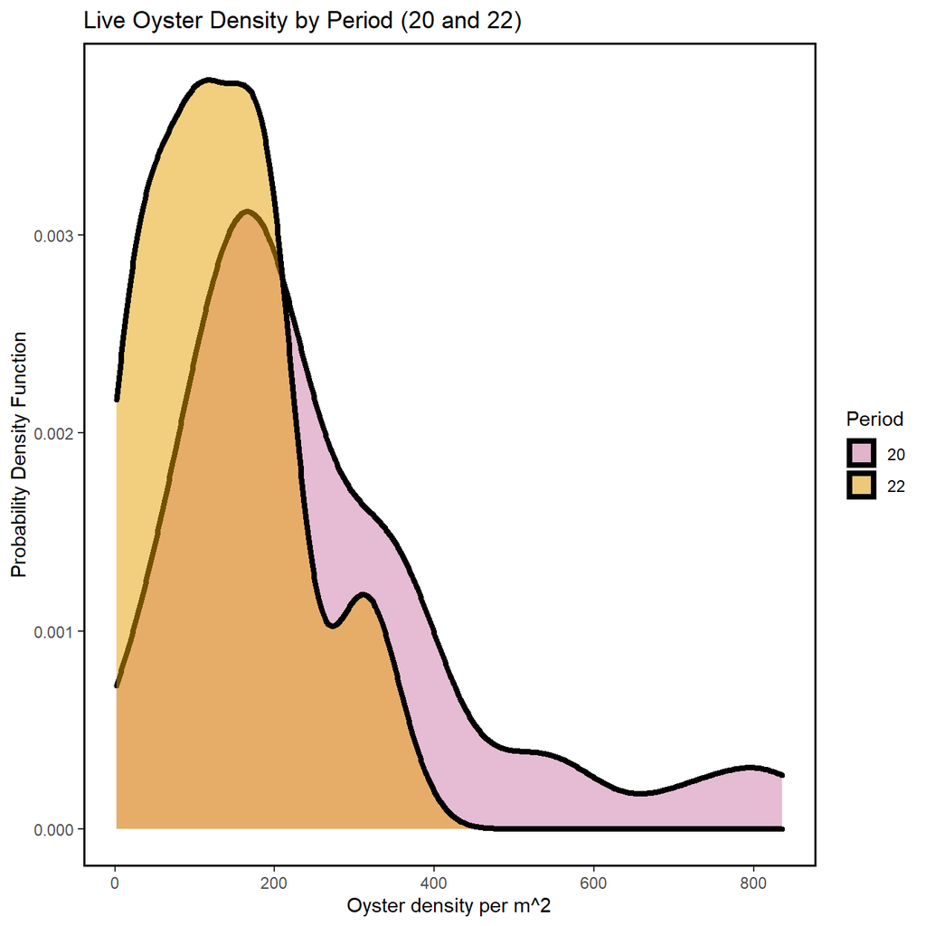

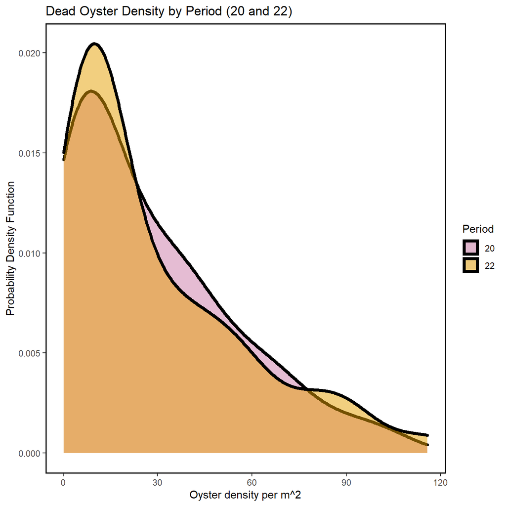

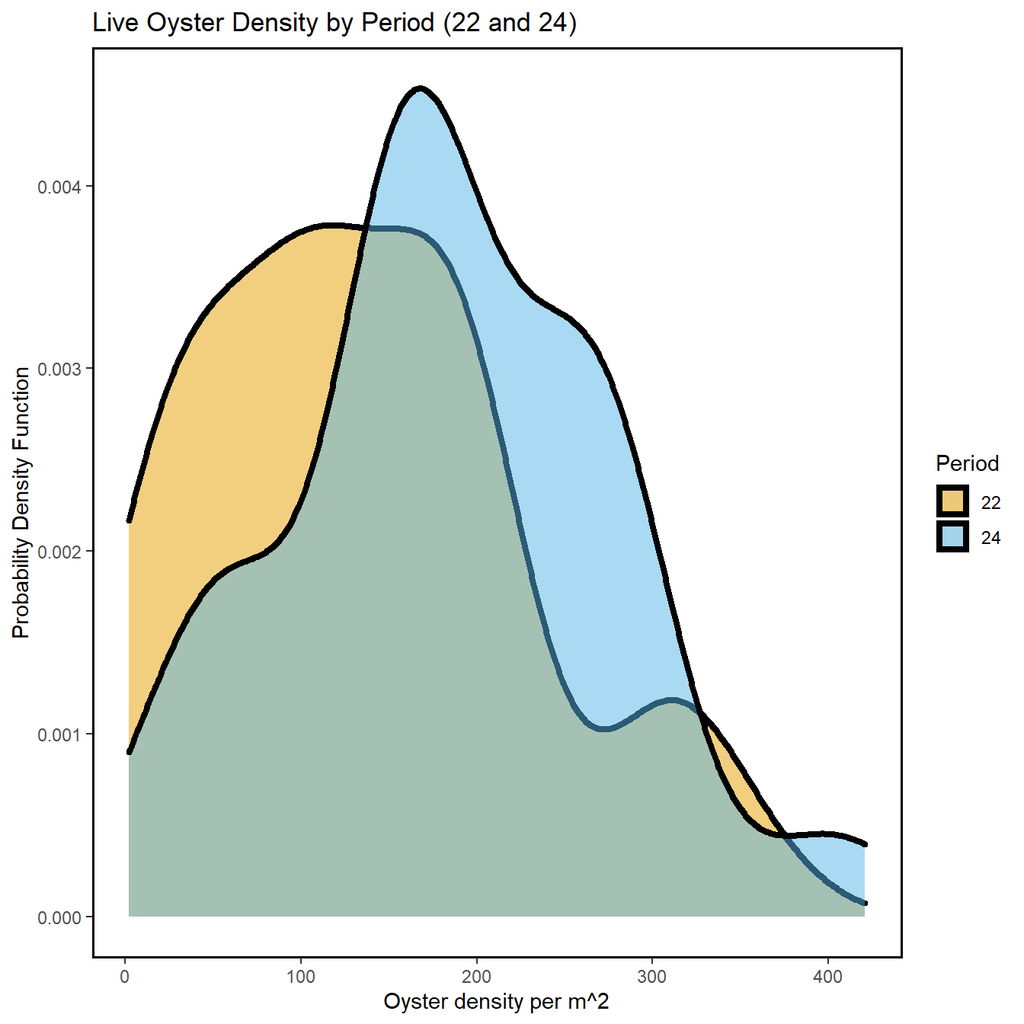

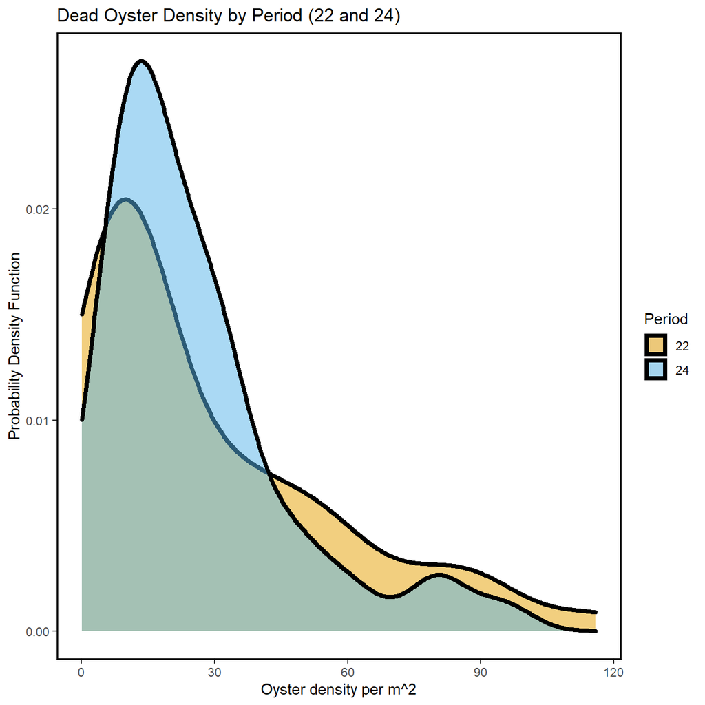

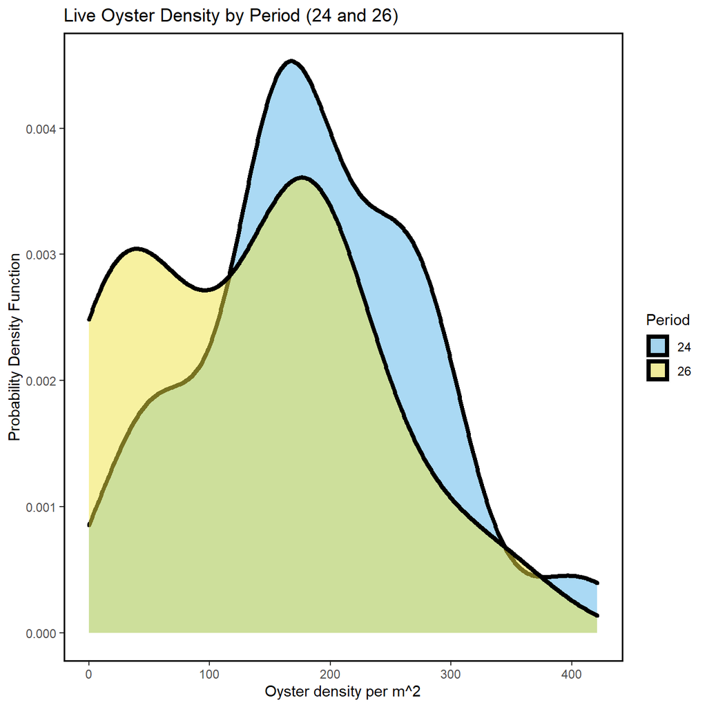

Figure- Calculated live oyster density by periods 24 (Winter 2021-2022) and 26 (Winter 2022-2023) using a probability density function with the last sample date of period 26 as 2023-01-24.

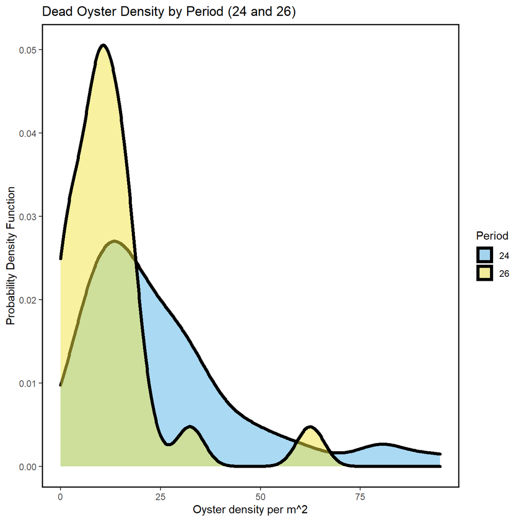

Figure- Calculated dead oyster density by periods 24 (Winter 2021-2022) and 26 (Winter 2022-2023) using a probability density function with the last sample date of period 26 as 2023-01-24.

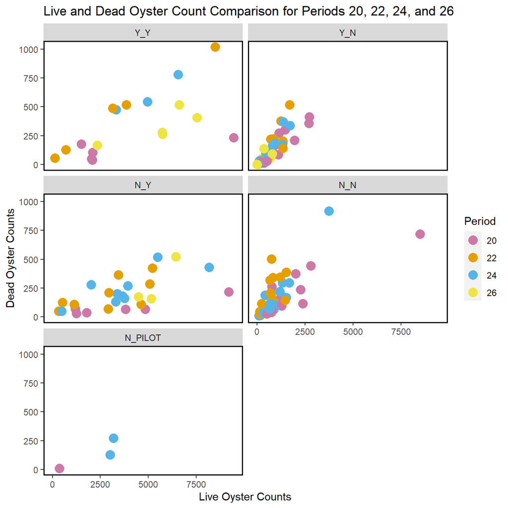

Figure- Live and dead oyster count comparison by periods 20 (Winter 2019-2020), 22 (Winter 2020-2021), 24 (Winter 2021-2022), and 26 (Winter 2022-2023) last sample date of period 26 as 2023-01-24.

## Live Counts Double Pass Results

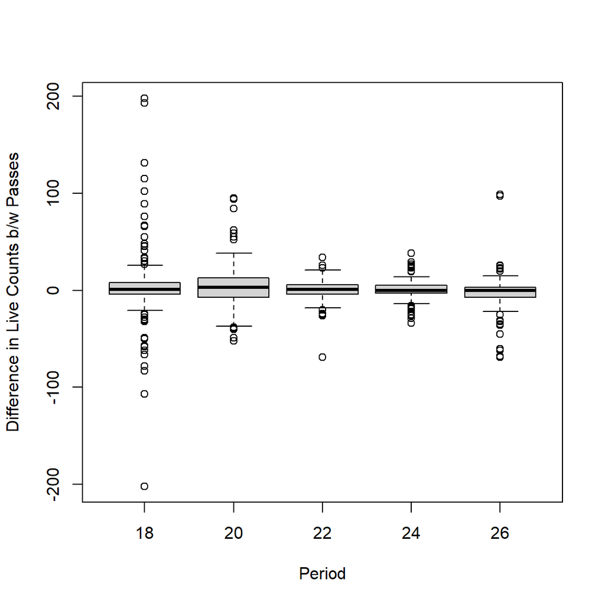

Figure- Boxplot of the difference in live counts between pass 1 and pass 2 (pass 1 live counts - pass 2 live counts) for period 18, 20, 22, 24, and 26

```
 locality period mean_difference sd_difference    CV
       BT     18           -5.43          60.0 -11.1
       LC     18            3.58          30.0   8.4
       NN     18           13.17          15.5   1.2
       LC     20            4.33          22.4   5.2
       LT     20            2.64          39.2  14.9
       BT     22           -1.00          18.9 -18.9
       LC     22            0.14           9.0  63.6
       LT     22            3.38          10.9   3.2
       BT     24            9.23          14.0   1.5
       LC     24           -0.44           8.7 -19.5
       LC     26           -1.87          23.0 -12.3
```

Table- Coefficient variation between pass 1 and pass 2, aggregated by locality and period for live counts

## Dead Counts Double Pass Results

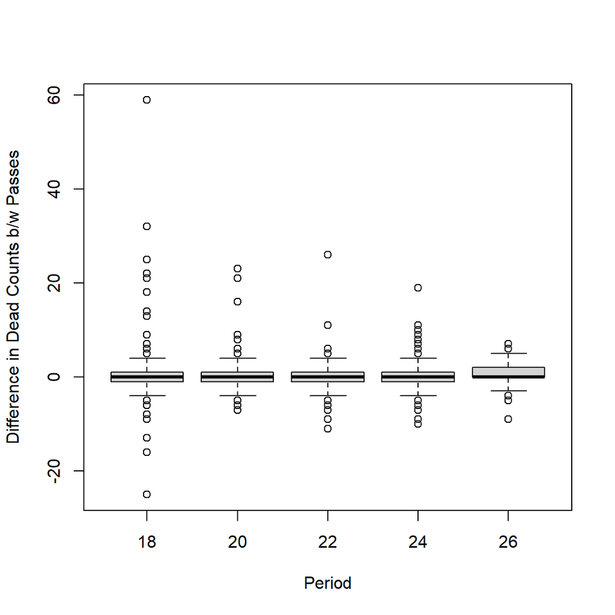

Figure- Boxplot of the difference in dead counts between pass 1 and pass 2 (pass 1 dead counts - pass 2 dead counts) for period 18, 20, 22, 24, and 26

```
 locality period CV_1 CV_2
       BT     18 0.78 0.82
       LC     18 2.35 2.06
       NN     18 0.55 0.73
       LC     20 1.93 1.62
       LT     20 0.76 0.67
       BT     22 0.60 0.66
       LC     22 1.09 1.07
       LT     22 0.69 0.66
       BT     24 0.54 0.51
       LC     24 1.13 1.11
       LC     26 0.88 1.13
```

Table- Coefficient variation between pass 1 and pass 2, aggregated by locality and period for dead counts

# Sampling for all Periods

Next, we provide summary tables and plots for all transect sampling. These data were collected between 2010-05-27 and 2023-01-24. The following are only for live oysters.

## Definitions of Periods

| PERIOD | SEASON | YEAR |
| --- | --- | --- |
| 1 | Summer | 2010 |
| 2 | Winter | 2010-2011 |
| 3 | Summer | 2011 |
| 4 | Winter | 2011-2012 |
| 5 | Summer | 2012 |
| 6 | Winter | 2012-2013 |
| 7 | Summer | 2013 |
| 8 | Winter | 2013-2014 |
| 9 | Summer | 2014 |
| 10 | Winter | 2014-2015 |
| 11 | Summer | 2015 |
| 12 | Winter | 2015-2016 |
| 13 | Summer | 2016 |
| 14 | Winter | 2016-2017 |
| 15 | Summer | 2017 |
| 16 | Winter | 2017-2018 |
| 17 | Summer | 2018 |
| 18 | Winter | 2018-2019 |
| 19 | Summer | 2019 |
| 20 | Winter | 2019-2020 |
| 21 | Summer | 2020 |
| 22 | Winter | 2020-2021 |
| 23 | Summer | 2021 |
| 24 | Winter | 2021-2022 |
| 25 | Summer | 2022 |
| 26 | Winter | 2022-2023 |

## Summary of Effort for all Periods

These effort summaries show the total number of transects and total number of meters walked per locality, strata, locality per period, and strata per period. **These tables contain all data collected on the transects.**

```
Effort by Locality
 Locality Number of Transects Total Length (m)
       BT                  19              640
       CK                  26              734
       CR                  46             1375
       HB                  45             1129
       LC                 255            15349
       LT                  21              542
       NN                  14              357

Effort by Strata
  Strata Number of Transects Total Length (m)
     N_N                 134             4379
 N_PILOT                  15             1050
     N_Y                  41             4897
```

[output cut: 104 more lines]

## Effort Plot Summaries for all Periods

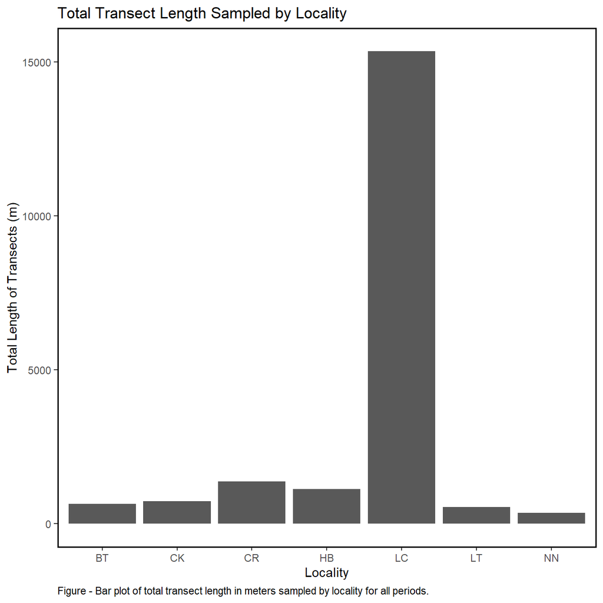

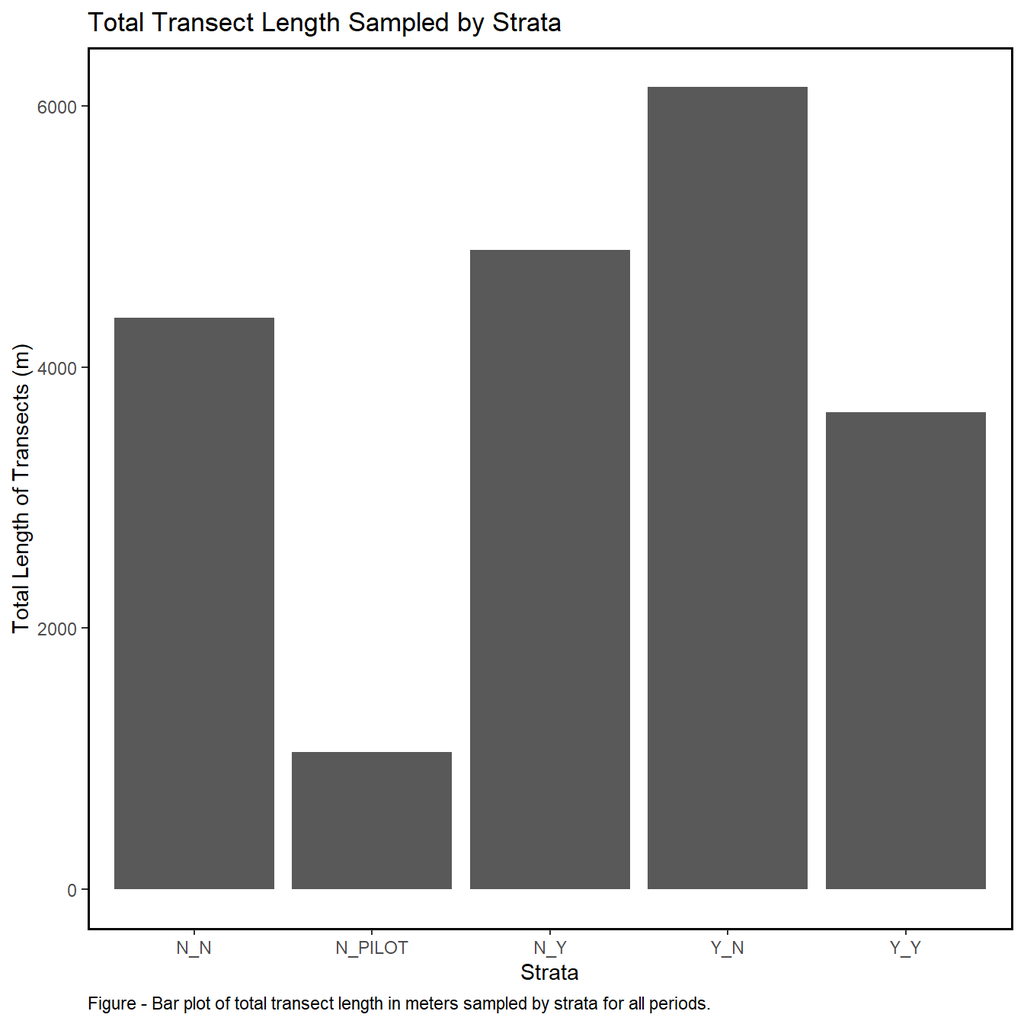

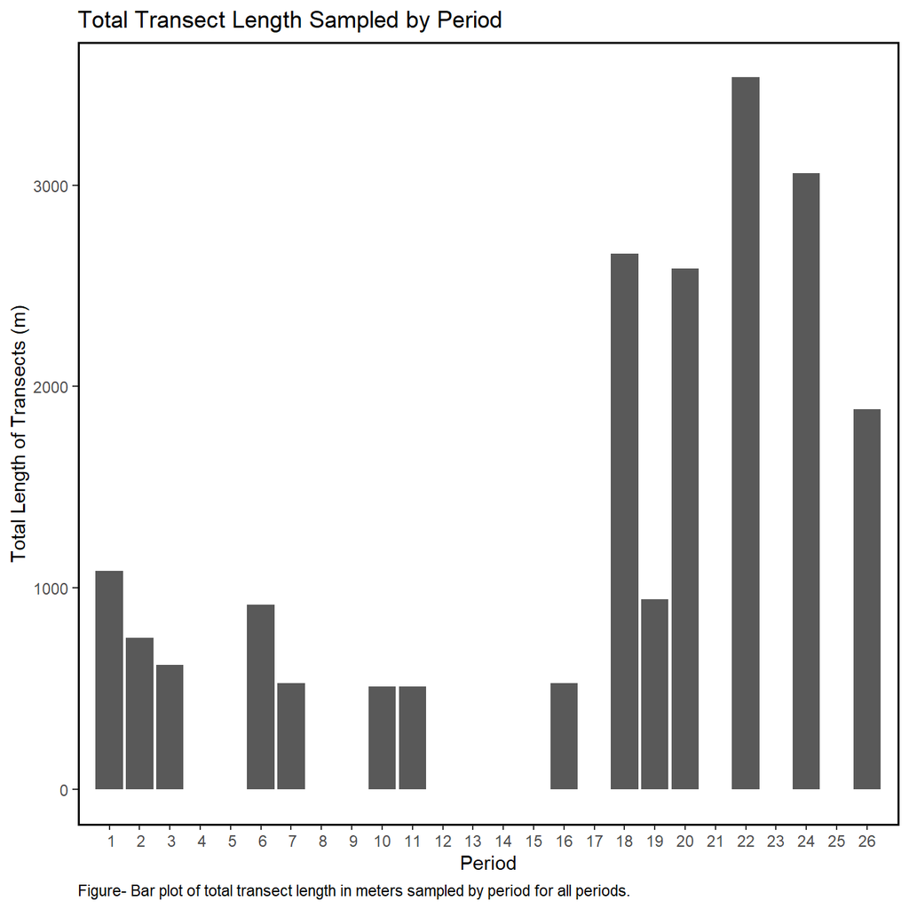

# Summary Tables for all Periods

These summaries display summary statistics of live oysters by locality, strata, and period. These contain all data collected on the oyster transects.

The summary statistics include:  
- Locality or Strata or Period - Mean  
- Median  
- Standard Deviation (SD)  
- Variance (Var)  
- Coefficient of variation (CV)  
- Standard Error (SE)  
- Lower 95% Confidence Interval assuming normal distribution (L95)  
- Upper 95% Confidence Interval assuming normal distribution (U95)  
- Bootstrap Mean (Bstrap Mean)  
- Lower 95% Confidence Interval from Bootstrap Values (L95 Bstrap)  
- Upper 95% Confidence Interval from Bootstrap Values (U95 Bstrap)

## Live Count Statistics for all Periods

```
Live Oyster Counts by Locality
 Locality Mean Median   SD     Var   CV  SE  L95  U95 Bstrap_Mean L95_Bstrap U95_Bstrap
       BT 1372    872 1908 3638919 1.39 438  514 2230        1374        736       2317
       CK  857    444 1091 1190933 1.27 214  438 1277         854        486       1255
       CR 1026    716 1035 1072162 1.01 153  727 1325        1027        746       1324
       HB  902    364 1047 1095622 1.16 158  592 1211         896        616       1226
       LC 1348    701 1737 3016086 1.29 110 1133 1563        1344       1135       1553
       LT 1026    877  551  303721 0.54 120  790 1262        1021        812       1288
       NN  735    674  584  341295 0.79 156  429 1041         737        477       1054

Live Oyster Counts by Strata
  Strata Mean Median   SD     Var   CV  SE  L95  U95 Bstrap_Mean L95_Bstrap U95_Bstrap
     N_N  989    766 1012 1025017 1.02  88  817 1161         995        837       1163
 N_PILOT 1318   1136  925  856059 0.70 239  850 1787        1323        906       1793
     N_Y 2912   3060 2212 4892643 0.76 345 2235 3589        2922       2298       3585
     Y_N  743    428  877  769929 1.18  61  624  862         743        635        861
     Y_Y 3551   2740 2891 8356742 0.81 616 2343 4759        3566       2430       4842

Live Oyster Counts by Period
 Period Mean Median   SD     Var   CV  SE  L95  U95 Bstrap_Mean L95_Bstrap U95_Bstrap
      1 1404   1018 1288 1657932 0.92 199 1014 1793        1397       1034       1798
      2  890    476  945  893727 1.06 176  546 1234         894        567       1235
      3  738    296  817  668064 1.11 167  411 1065         737        404       1061
      6  433    176  534  284791 1.23  96  245  621         426        259        609
      7   50     29   56    3186 1.12  20   11   90          51         17         91
     10 1207   1074  671  449607 0.56 237  743 1672        1218        848       1689
     11  886    776  678  459708 0.77 240  416 1356         879        507       1360
     16  494    366  467  217855 0.95 165  170  817         495        225        798
     18  982    695  935  874733 0.95 120  748 1217         980        766       1213
     19  555    329  573  328431 1.03  97  365  745         558        379        757
     20 1844   1253 2125 4517189 1.15 310 1236 2451        1856       1302       2531
     22 1334    702 1693 2867783 1.27 242  860 1808        1326        908       1804
     24 1729    942 1845 3403035 1.07 266 1207 2251        1716       1240       2224
     26 2394    730 2677 7164223 1.12 571 1276 3513        2423       1391       3544
```

## Live Density Statistics for all Periods

```
Live Density by Locality
 Locality Mean Median  SD    Var   CV   SE L95 U95 Bstrap_Mean L95_Bstrap U95_Bstrap
       BT  238    218 168  28363 0.71 38.6 162 313         237        170        313
       CK  241    112 321 102927 1.33 62.9 118 364         239        119        364
       CR  283    178 294  86605 1.04 43.4 198 368         284        207        367
       HB  257    101 303  92052 1.18 45.7 168 347         257        172        353
       LC  154    133 137  18876 0.89  8.7 137 171         154        138        171
       LT  279    261 132  17460 0.47 28.8 222 335         278        228        335
       NN  215    174 202  40919 0.94 54.1 109 321         216        127        334

Live Density by Strata
  Strata Mean Median  SD   Var   CV SE L95 U95 Bstrap_Mean L95_Bstrap U95_Bstrap
     N_N  253    190 239 56963 0.94 21 212 294         252        211        293
 N_PILOT  118    121  59  3467 0.50 15  88 148         118         90        148
     N_Y  164    159  91  8351 0.56 14 136 192         164        137        191
     Y_N  179    117 208 43104 1.16 14 151 207         179        153        208
     Y_Y  135    145  80  6438 0.59 17 102 169         135        101        169


Live Density by Period
 Period Mean Median    SD    Var   CV SE   L95   U95 Bstrap_Mean L95_Bstrap U95_Bstrap
      1  393  300.8 362.6 131444 0.92 56 283.8 503.1         394      286.6        511
      2  255  119.0 285.2  81348 1.12 53 151.3 358.9         254      159.7        358
      3  234   85.3 269.3  72523 1.15 55 126.1 341.6         237      137.5        341
      6  121   72.2 150.9  22767 1.25 27  68.1 174.3         121       73.0        176
      7    5    2.9   5.6     31 1.12  2   1.1   8.9           5        1.7          9
     10  124  113.3  67.4   4536 0.54 24  76.9 170.3         123       87.4        167
     11   90   79.5  67.8   4596 0.75 24  43.4 137.4          90       46.6        137
     16   49   36.3  46.4   2154 0.95 16  16.9  81.2          49       20.1         81
     18  176  154.5 130.2  16945 0.74 17 143.7 209.0         177      144.5        211
     19  154   72.7 168.5  28408 1.10 28  97.9 209.6         153       99.8        209
     20  256  202.8 187.2  35057 0.73 27 202.6 309.6         256      208.1        309
     22  137  120.6  92.9   8638 0.68 13 111.2 163.3         137      111.9        162
     24  185  180.6  91.6   8385 0.49 13 159.3 211.1         185      159.4        210
     26  148  167.6  93.9   8809 0.63 20 108.7 187.1         148      111.5        187
```

## Dead Count Statistics for all Periods

```
Dead Oyster Counts by Locality
 Locality Mean Median  SD   Var   CV SE   L95 U95 Bstrap_Mean L95_Bstrap U95_Bstrap
       BT  249    160 278 77231 1.12 64 123.6 374         250        141        375
       CK   78     32 106 11170 1.36 37   4.3 151          76         16        149
       CR   60     47  38  1444 0.63 13  35.2  85          59         39         86
       HB   44     21  45  2000 1.02 15  14.8  73          44         18         73
       LC  134     73 159 25199 1.19 11 112.3 155         133        112        156
       LT  218    141 180 32543 0.83 39 140.5 295         217        151        293
       NN   98     72  87  7493 0.88 23  52.5 143          99         60        146

Dead Oyster Counts by Strata
  Strata Mean Median  SD   Var   CV SE L95 U95 Bstrap_Mean L95_Bstrap U95_Bstrap
     N_N  157     96 189 35865 1.21 19 120 193         157        124        194
 N_PILOT   98     89  65  4243 0.67 17  65 131          98         68        132
     N_Y  145     70 141 19786 0.97 22 102 188         144        103        187
     Y_N   98     54 110 12129 1.13 10  77 118          97         78        118
     Y_Y  286    204 276 75913 0.96 59 171 401         283        175        393

Dead Oyster Counts by Period
 Period Mean Median  SD   Var   CV   SE   L95 U95 Bstrap_Mean L95_Bstrap U95_Bstrap
      7   29     18  30   898 1.03 10.6   8.2  50          29         12         51
     10   80     88  65  4245 0.82 23.0  34.5 125          79         42        124
     11   50     40  25   620 0.49  8.8  33.2  68          51         36         67
     16   44     28  41  1708 0.93 14.6  15.6  73          44         19         71
     18  133     55 192 36903 1.44 24.6  85.1 182         133         89        183
     19   63     44  67  4548 1.08 11.6  40.0  85          63         42         88
     20  148    107 140 19727 0.95 20.5 107.6 188         147        110        187
     22  191    128 193 37399 1.01 27.6 137.2 245         191        140        248
     24  192    130 194 37816 1.01 28.1 136.8 247         192        144        246
     26  148     93 156 24439 1.06 32.6  83.6 211         147         91        216
```

## Dead Density Statistics for all Periods

```
Dead Oyster Density by Locality
 Locality Mean Median SD  Var   CV  SE  L95 U95 Bstrap_Mean L95_Bstrap U95_Bstrap
       BT   46     34 33 1076 0.72 7.5 30.9  60          46       33.2         61
       CK   21     11 28  757 1.29 9.7  2.3  40          21        5.5         41
       CR   18     11 16  247 0.87 5.2  7.8  28          18        9.7         29
       HB   13      8 14  201 1.12 4.7  3.4  22          13        4.5         22
       LC   18     11 20  402 1.14 1.4 14.9  20          18       14.8         21
       LT   54     47 35 1232 0.64 7.7 39.5  70          54       39.9         69
       NN   28     21 22  463 0.78 5.7 16.4  39          28       17.6         39

Dead Oyster Density by Strata
  Strata Mean Median   SD Var   CV   SE  L95  U95 Bstrap_Mean L95_Bstrap U95_Bstrap
     N_N 33.1   27.7 30.5 928 0.92 3.02 27.2 39.0        33.2       27.2       39.3
 N_PILOT  8.7    8.7  4.3  18 0.49 1.11  6.5 10.9         8.7        6.7       11.2
     N_Y  8.0    8.0  5.7  33 0.71 0.89  6.3  9.8         8.0        6.4        9.7
     Y_N 22.3   13.5 23.2 536 1.04 2.17 18.1 26.6        22.5       18.6       26.7
     Y_Y 10.3   10.6  6.2  38 0.60 1.32  7.7 12.9        10.3        7.7       12.8


Dead Oyster Density by Period
 Period Mean Median   SD   Var   CV   SE   L95  U95 Bstrap_Mean L95_Bstrap U95_Bstrap
      7  2.9    1.8  3.0   8.9 1.03 1.05  0.82  4.9         2.9        1.0        4.9
     10  8.2    8.9  6.6  44.0 0.81 2.35  3.58 12.8         8.3        4.4       12.7
     11  5.2    4.1  2.6   6.6 0.49 0.91  3.41  7.0         5.2        3.5        6.9
     16  4.4    2.8  4.1  16.9 0.93 1.45  1.55  7.2         4.4        1.8        7.1
     18 26.4   15.7 31.3 979.8 1.19 4.01 18.50 34.2        26.3       18.4       34.6
     19 17.5   10.5 19.3 371.9 1.10 3.31 11.06 24.0        17.6       11.7       23.9
     20 27.7   18.4 26.1 681.6 0.94 3.81 20.24 35.2        27.9       21.1       35.7
     22 28.5   14.2 28.4 807.0 1.00 4.06 20.53 36.4        28.5       21.6       36.8
     24 25.7   19.1 20.9 438.3 0.81 3.02 19.83 31.7        25.8       20.1       32.0
     26 13.3   10.6 12.9 166.0 0.97 2.69  8.02 18.6        13.4        9.0       19.3
```

## Summary Density Plots for all Periods

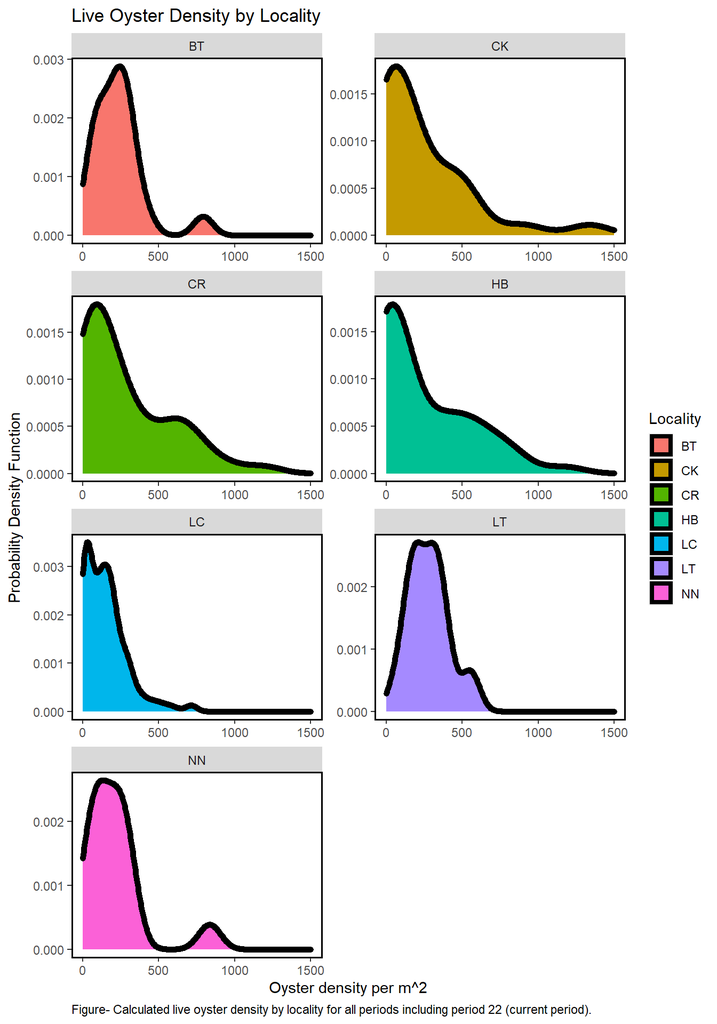

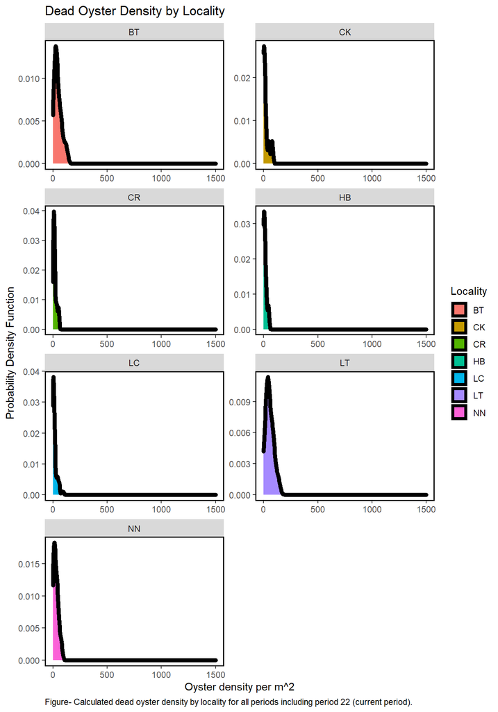

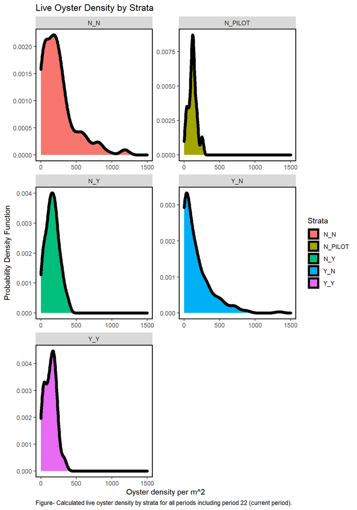

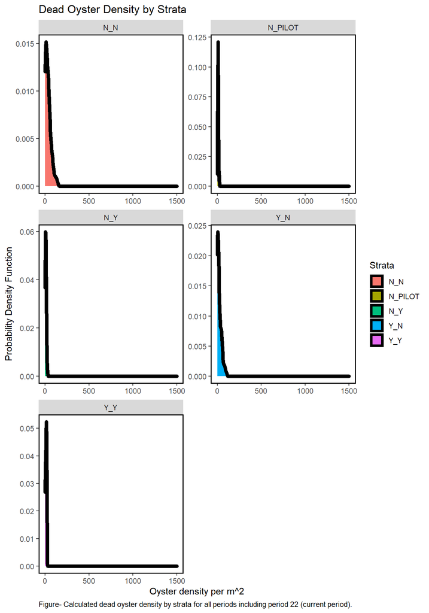

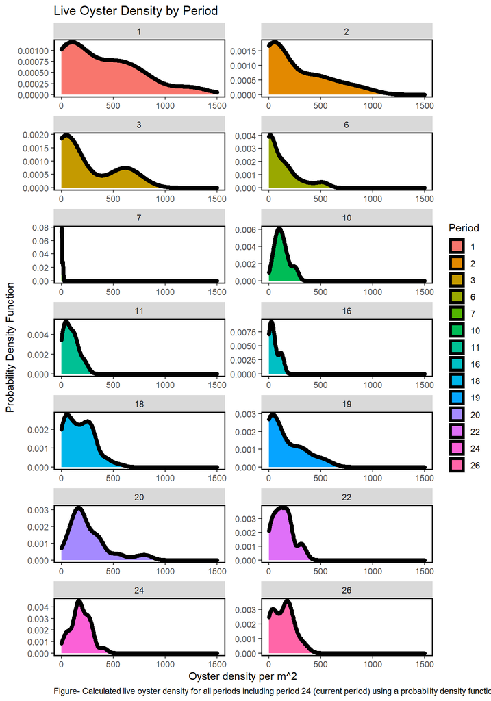

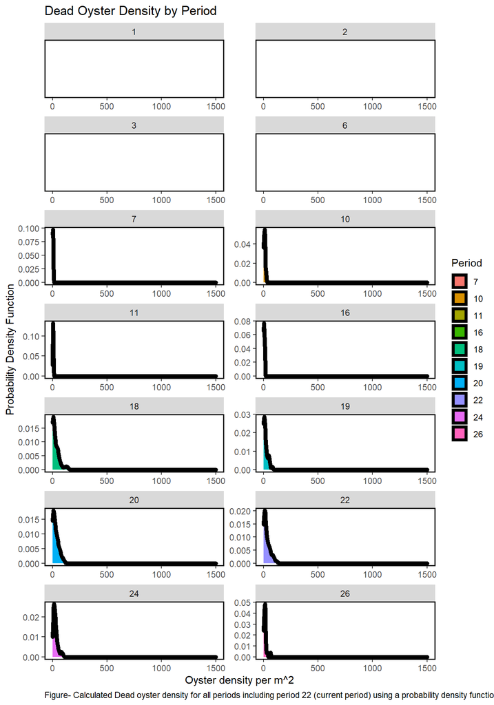

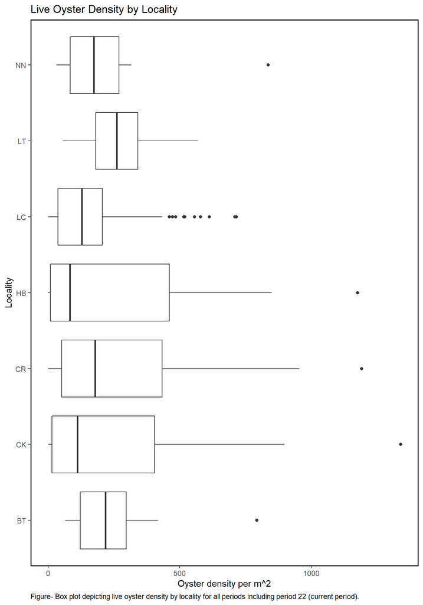

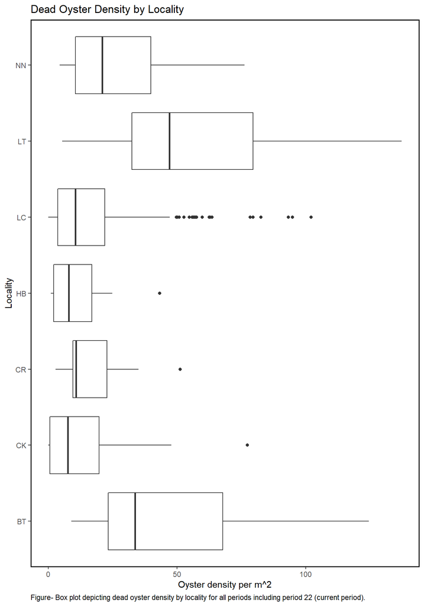

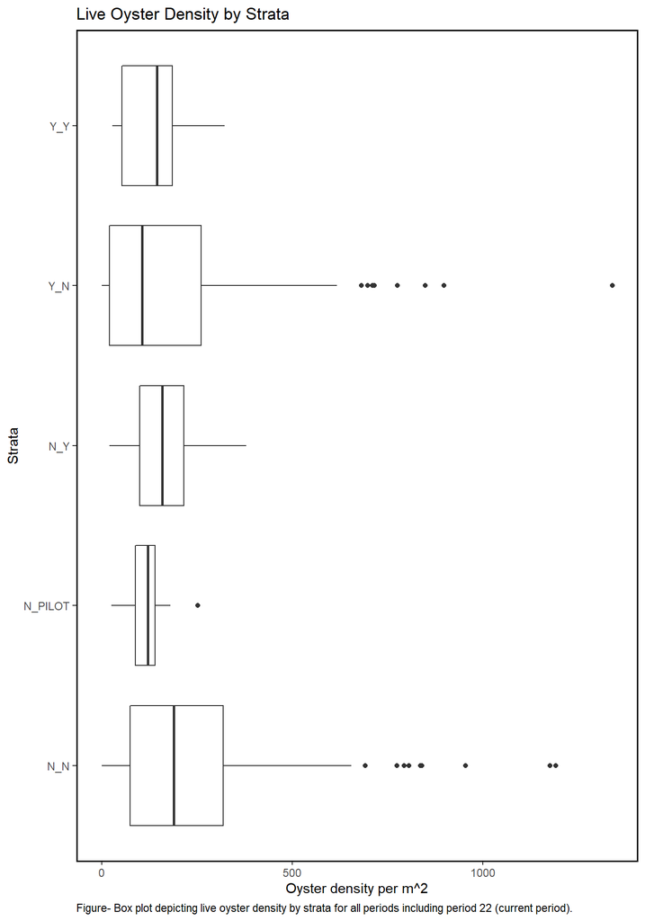

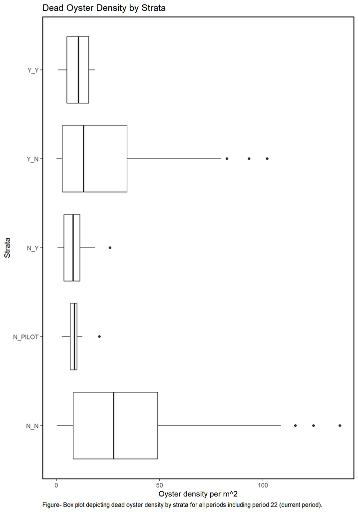

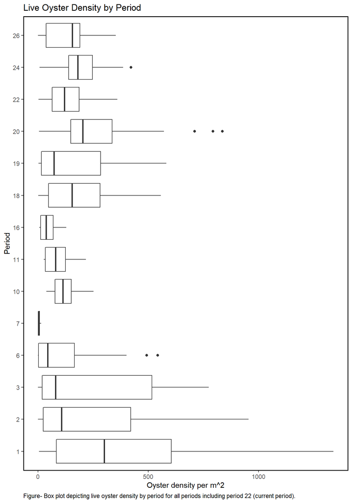

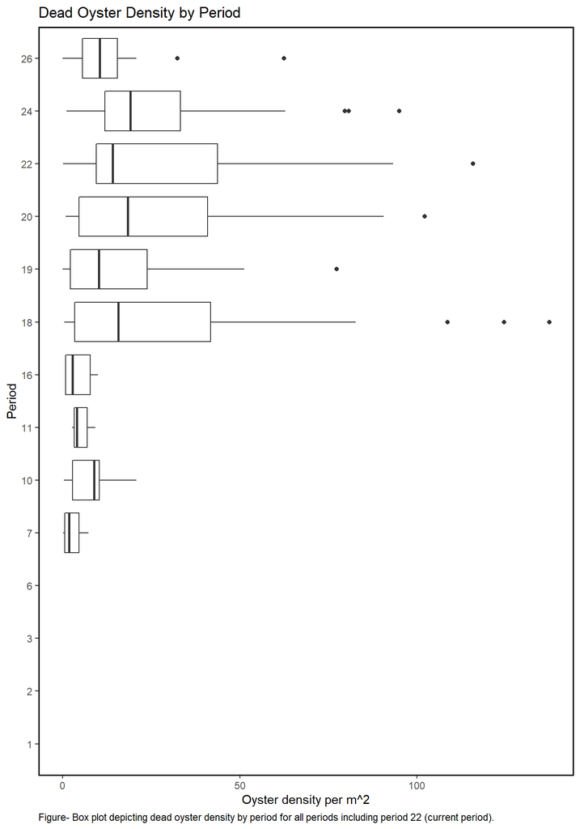

[5 more figures not shown]

Figure- Live and dead oyster comparison for all periods, last sample date of period 26 is 2023-01-24.

# Summary Plots for Pilot Study Sites

A subset of the oyster transect locations were sampled over time for a pilot study. Here we provide plots of live oyster counts and density for these pilot stations with Lone Cabbage (LCO10B, LCO11A, LCO8B, LCO9A).

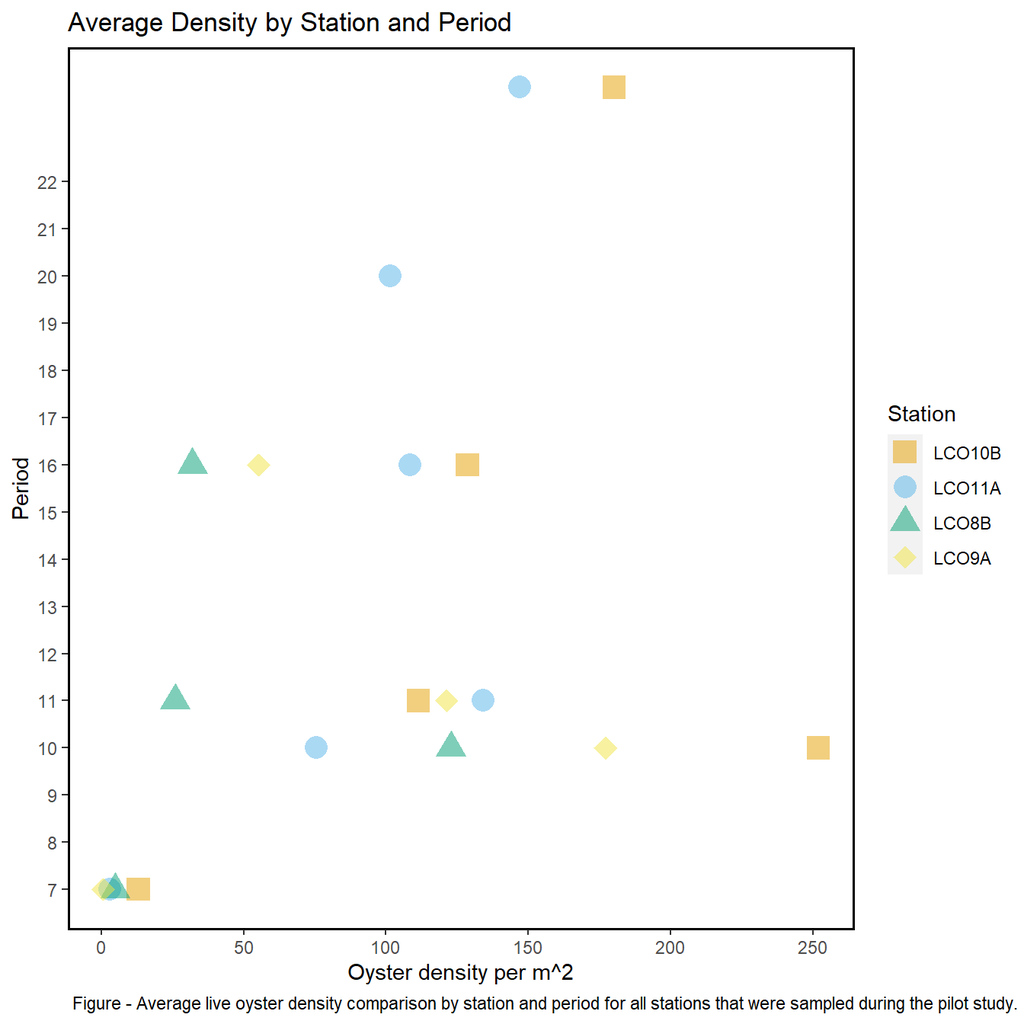

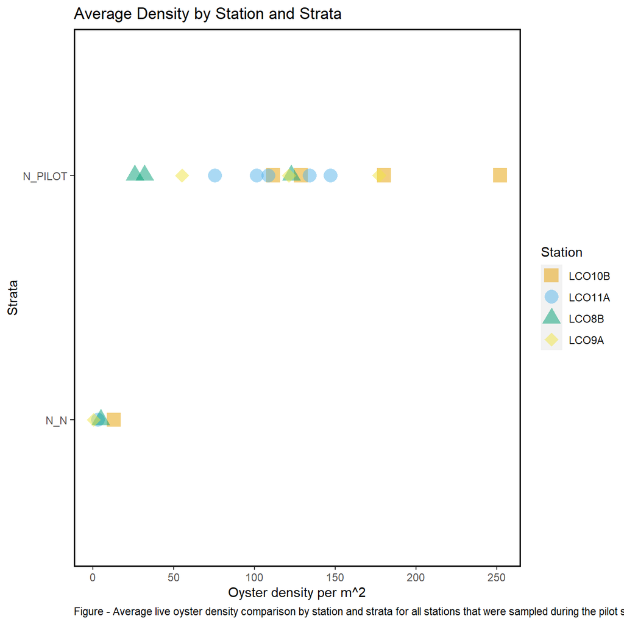

# Latest Data Entered

Displayed are the entries for the last date of sampling (2023-01-24).

```
       date station tran_length count_live count_dead treatment strata
 2023-01-24   LCO22         2.5         41          6     rocks    Y_Y
 2023-01-24   LCO22         5.0         54          7     rocks    Y_Y
 2023-01-24   LCO22         7.5         99         10     rocks    Y_Y
 2023-01-24   LCO22        10.0         60          8     rocks    Y_Y
 2023-01-24   LCO22        12.5         91          4     rocks    Y_Y
 2023-01-24   LCO22        15.0         21          5     rocks    Y_Y
 2023-01-24   LCO22        17.5         14          1     rocks    Y_Y
 2023-01-24   LCO22        20.0         62         10     rocks    Y_Y
 2023-01-24   LCO22        22.0         46          7     rocks    Y_Y
 2023-01-24   LCO22        22.1          2          0     rocks    Y_Y
 2023-01-24   LCO22         2.5        102          2     rocks    Y_Y
 2023-01-24   LCO22         5.0         40          1     rocks    Y_Y
 2023-01-24   LCO22         7.5         11          1     rocks    Y_Y
 2023-01-24   LCO22        10.0         73          0     rocks    Y_Y
 2023-01-24   LCO22        12.5        124         11     rocks    Y_Y
 2023-01-24   LCO22        15.0        132         13     rocks    Y_Y
 2023-01-24   LCO22        17.5        158         18     rocks    Y_Y
 2023-01-24   LCO22        20.0        104          4     rocks    Y_Y
 2023-01-24   LCO22        22.0         81          3     rocks    Y_Y
 2023-01-24   LCO22        22.8         33          1     rocks    Y_Y
 2023-01-24   LCO22         2.5        201          5     rocks    Y_Y
 2023-01-24   LCO22         5.0        172          3     rocks    Y_Y
 2023-01-24   LCO22         7.5        117          8     rocks    Y_Y
 2023-01-24   LCO22        10.0         83          4     rocks    Y_Y
 2023-01-24   LCO22        12.5         81          8     rocks    Y_Y
 2023-01-24   LCO22        15.0         95         10     rocks    Y_Y
 2023-01-24   LCO22        17.5         86          9     rocks    Y_Y
 2023-01-24   LCO22        20.0         80          6     rocks    Y_Y
 2023-01-24   LCO22        21.4         78          2     rocks    Y_Y
 2023-01-24   LCO21         2.5          0          1     rocks    Y_Y
 2023-01-24   LCO21         5.0          5          0     rocks    Y_Y
 2023-01-24   LCO21         7.5          3          0     rocks    Y_Y
 2023-01-24   LCO21        10.0         14          0     rocks    Y_Y
 2023-01-24   LCO21        12.5         32          4     rocks    Y_Y
 2023-01-24   LCO21        15.0         23          3     rocks    Y_Y
 2023-01-24   LCO21        17.5         50          4     rocks    Y_Y
 2023-01-24   LCO21        20.0          5          3     rocks    Y_Y
 2023-01-24   LCO21        22.0         36          8     rocks    Y_Y
 2023-01-24   LCO21        25.0          4          0     rocks    Y_Y
```

[output cut: 86 more lines]

```
 2023-01-24   LCO21        22.0         93          7     rocks    Y_Y
 2023-01-24   LCO21        23.1         73         14     rocks    Y_Y
 2023-01-24   LCI42         2.5          3          1   control   <NA>
 2023-01-24   LCI42         5.0          9          1   control   <NA>
 2023-01-24   LCI42         7.5         88         10   control   <NA>
 2023-01-24   LCI42        10.0         59          8   control   <NA>
 2023-01-24   LCI42        12.5         34          1   control   <NA>
 2023-01-24   LCI42        15.0         67          3   control   <NA>
 2023-01-24   LCI42        17.5          0          0   control   <NA>
 2023-01-24   LCI42        20.0          0          0   control   <NA>
 2023-01-24   LCI42        22.5          2          0   control   <NA>
 2023-01-24   LCI42        25.0        114         22   control   <NA>
 2023-01-24   LCI42        27.5         47          5   control   <NA>
 2023-01-24   LCI42        30.0         62          8   control   <NA>
 2023-01-24   LCI42        31.2          8          1   control   <NA>
```